# Lab2

Problem 1

```python
import numpy as np
import matplotlib
import matplotlib.pyplot as plt
import scipy
from scipy import stats
```

Part a. The distribution is set up using the stats.poisson.pmf package, and the noise of the background of these gamma-ray sources is set to have values from 0 to 10, and the average is set to be 6. The probability of a sum of the distribution can be calculated with convolution, and it is set up using the np.convolve package to inteagrate the probability mass function of the past day with the current day, and continue to get the results for more days.

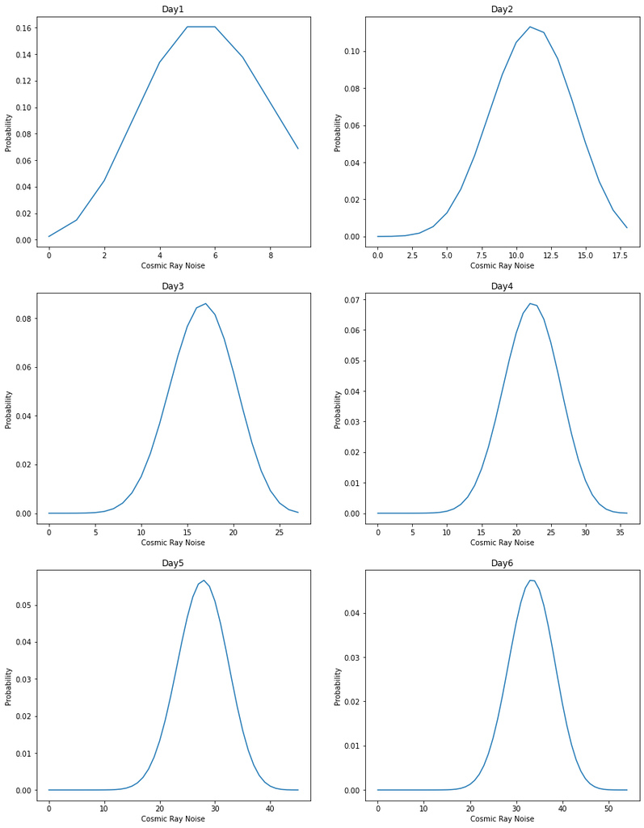

```python
plt.rcParams["figure.figsize"] = (15,20)
fig, ax = plt.subplots(3, 2)

x = np.arange(0,10)
y = stats.poisson.pmf(x,mu = 6)
ax[0,0].plot(x,y)
ax[0,0].set_xlabel("Cosmic Ray Noise");
ax[0,0].set_ylabel("Probability");
ax[0,0].set_title("Day1");

y2 = np.convolve(y, y);
x2 = np.arange(0, 19)
ax[0,1].plot(x2,y2);
ax[0,1].set_xlabel("Cosmic Ray Noise");
ax[0,1].set_ylabel("Probability");
ax[0,1].set_title("Day2");

y3 = np.convolve(y2, y);
x3 = np.arange(0,28)
ax[1,0].plot(x3, y3);
ax[1,0].set_xlabel("Cosmic Ray Noise");
ax[1,0].set_ylabel("Probability");
ax[1,0].set_title("Day3");

y4 = np.convolve(y3, y);
x4 = np.arange(0,37)
ax[1,1].plot(x4, y4);
ax[1,1].set_xlabel("Cosmic Ray Noise");
ax[1,1].set_ylabel("Probability");
ax[1,1].set_title("Day4");

y5 = np.convolve(y4, y);
x5 = np.arange(0, 46)
ax[2,0].plot(x5, y5);
ax[2,0].set_xlabel("Cosmic Ray Noise");
ax[2,0].set_ylabel("Probability");
ax[2,0].set_title("Day5");

y6 = np.convolve(y5, y);
x6 = np.arange(0, 55)
ax[2,1].plot(x6, y6);
ax[2,1].set_xlabel("Cosmic Ray Noise");
ax[2,1].set_ylabel("Probability");
ax[2,1].set_title("Day6");

plt.show()
```

Part B. This is a comparison of the sum of over five days of the distribution, with a generated Poisson distribution. The Red line is the generated Poisson distribution and the blue line is the day five sum of the distribution.

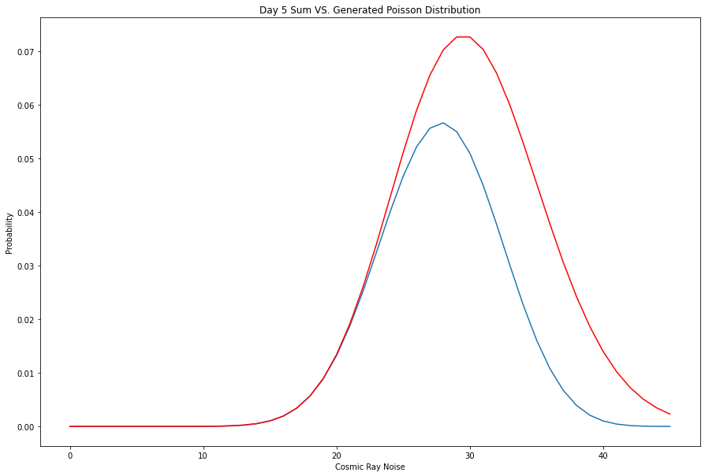

```python
plt.rcParams["figure.figsize"] = (15,10)
fig, ax = plt.subplots(1, 1)
ax.set_title("Day 5 Sum VS. Generated Poisson Distribution")
ax.set_xlabel("Cosmic Ray Noise")
ax.set_ylabel("Probability")
ax.plot(x5, y5);
ax.plot(x5, stats.poisson.pmf(x5, 6*5), color = "r")

plt.show()
```

Part C. This is the probability distribution as each is averaged. The sum is taken from part A and it is divided by the day passed to get the average of each day.

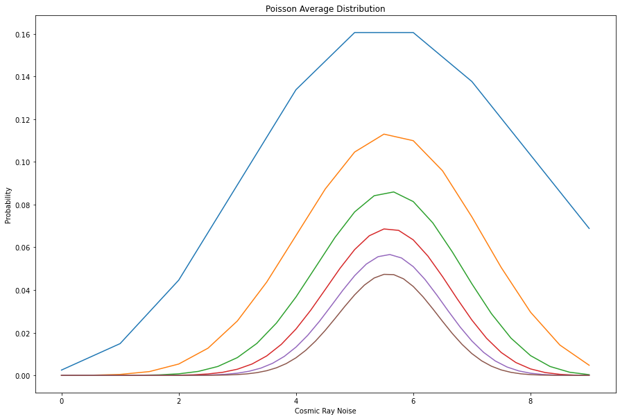

```python
plt.rcParams["figure.figsize"] = (15,10)
fig, ax = plt.subplots(1, 1)
ax.plot(x, y);
ax.plot(x2 / 2, y2);
ax.plot(x3 / 3, y3);
ax.plot(x4 / 4, y4);
ax.plot(x5 / 5, y5);
ax.plot(x6 / 6, y6);
ax.set_title("Poisson Average Distribution")
ax.set_xlabel("Cosmic Ray Noise")
ax.set_ylabel("Probability")

plt.show()
```

The average mean of the distribution stays the same, and the main change is the standard deviation of all of the distribution is smaller as the day goes on.

Part D. The number of days will be 6 days, and Y is 8. The sigma is calcualted by first accumulating the noise that is bigger than 8 * 6 which is 48, and to find the sigma the function stats.norm.ppf is used, which is 1 - the accumulated probability. The final sigma is around 3.506.

```python
prob = 0
for i, val in enumerate(y6):
    if (i > 8*6):
        prob += val

stats.norm.ppf(1-prob)
```

```
3.506376406768917
```

Problem 2

Part A. The distribution is set up using the function stats.rayleigh.pdf, and this set up the sum of the distribution over multiple days.

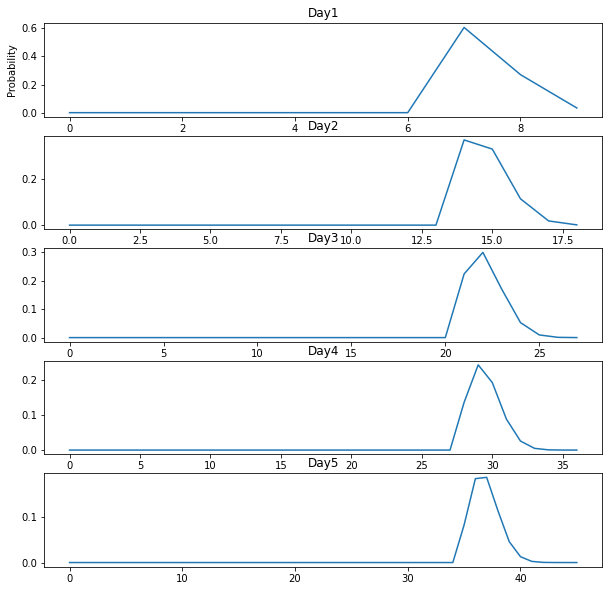

```python
plt.rcParams["figure.figsize"] = (10,10)
fig, ax = plt.subplots(5, 1)

x = np.arange(0,10)
y = stats.rayleigh.pdf(x,loc = 6)
ax[0].plot(x,y)
ax[0].set_xlabel("Number of Rays");
ax[0].set_ylabel("Probability");
ax[0].set_title("Day1");

y2 = np.convolve(y, y);
x2 = np.arange(0, 19)
ax[1].plot(x2,y2);
ax[1].set_title("Day2");

y3 = np.convolve(y2, y);
x3 = np.arange(0,28)
ax[2].plot(x3, y3);
ax[2].set_title("Day3");

y4 = np.convolve(y3, y);
x4 = np.arange(0,37)
ax[3].plot(x4, y4);
ax[3].set_title("Day4");

y5 = np.convolve(y4, y);
x5 = np.arange(0, 46)
ax[4].plot(x5, y5);
ax[4].set_title("Day5");

plt.show()
```

Part A. This sets up the average of the Rayleigh distribution over multiple days, and the mean stays the same for all of the average, but the total probability decreased.

Part B. The shape also changed throughout the days, when it is on day one, the shape is more of a sharp triangle, but the distribution slowly change into more and more gaussian.

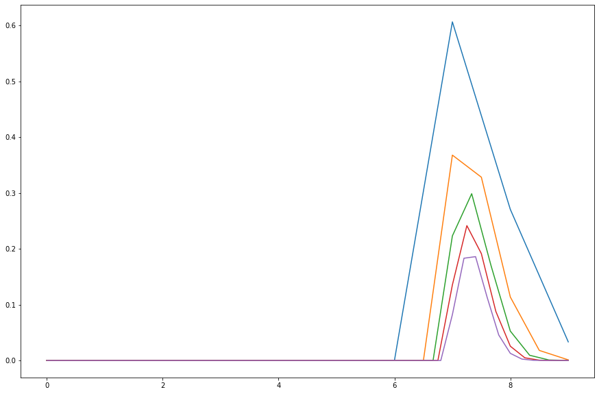

```python
plt.rcParams["figure.figsize"] = (15,10)
fig, ax = plt.subplots(1, 1)
ax.plot(x, y);
ax.plot(x2 / 2, y2);
ax.plot(x3 / 3, y3);
ax.plot(x4 / 4, y4);
ax.plot(x5 / 5, y5);

plt.show()
```

Problem 3

```python
temp = stats.norm.cdf(0.3)
temp
```

```
0.6179114221889526
```

```python
stats.norm.ppf(1 - temp)
```

```
-0.2999999999999998
```

Version 2 Part B. The mean of the probability distribution will stay the same, but the total probability wil go down for all pixels, as there are 10000 pixels now instead of only comparing one pixel in part A.

```python
x = np.linspace(0,3,1000)
d = stats.norm.pdf(x, loc = 1.0, scale = .01) * 10000
```

Part C.

```python
temp2 = stats.norm.cdf(0.3) * 10000

stats.norm.ppf(1 - temp2)
```

```
nan
```

Problem 4

Part A. This is the signal required for a 5 sigma detection in version 1.

```python
stats.norm.cdf(5)
```

```
0.9999997133484281
```

Part B. This is the signal required for a 5 sigma detection in version 2.

```python
stats.norm.cdf(0.00005)
```

```
0.5000199471140118
```

Part C. The signal has to be at least twice the strength for it to be significant for 10000 pixels, and it is because there are more pixels, the likelihood of reaching the max signal is very likely, and the strength has to be twice of the strongest average signal to be considered significant.

Part D. If the trial factor is changed significally, it will also change the sigma significally as it takes stronger and stronger signal to reach the 5 sigma detection value.